# PEER ASSESSMENT 1 - REPRODUCIBLE RESEARCH

By Casey Tsui  
Format: R Markdown  
Last updated: 7/19/14

## Author’s notes

This markdown code downloads, loads, and analyzes the physical activity data from a personal activity monitoring device. This device collects data at 5 minute intervals through out the day. The data consists of two months of data from an anonymous individual collected during the months of October and November, 2012 and include the number of steps taken in 5 minute intervals each day.

## Download the data into a temp file and then load data

First I download the data from the internet, then I load the data into memory into the object named “data”.

```r
# Libraries
library(plyr)
library(ggplot2)

# Download data to temp file
f <- tempfile()
file_url <- "https://d396qusza40orc.cloudfront.net/repdata%2Fdata%2Factivity.zip"
download.file(file_url, destfile=f, method="curl")

# Unzip the file and read in data
data <- read.csv(unzip(f))
```

## Clean data

The dates in the file are then converted to standard format: YYYY-MM-DD.

```r
data$date <- as.Date(data$date, "%Y-%m-%d")
```

## Analysis

I then calculated the total number of steps taken each day.

```r
totalsteps <- ddply(data,
                    .(date),
                    function(df)
                        c(totalsteps = sum(df$steps, na.rm=TRUE)))
```

Here’s a histogram of total number of steps taken each day:

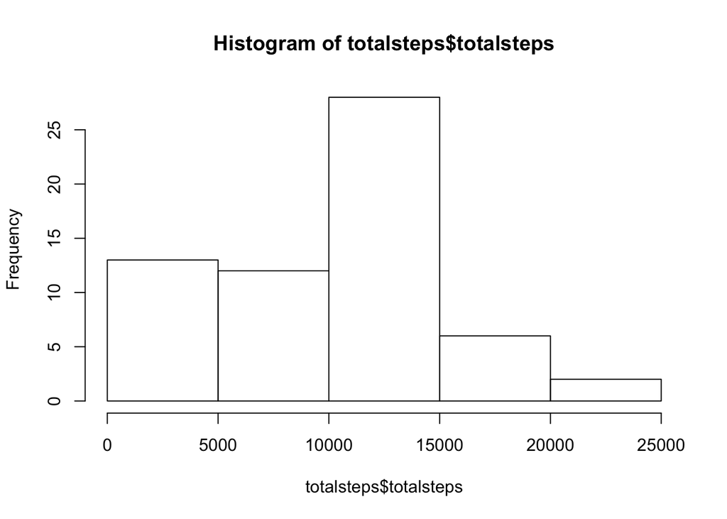

```r
hist(totalsteps$totalsteps)
```

Next, I calculate the mean and median of the total steps

```r
mean_steps <- mean(totalsteps$totalsteps, na.rm=TRUE)
median_steps <- median(totalsteps$totalsteps, na.rm=TRUE)
```

The mean number of total steps is 9354.2295 and the median number of total steps is 10395.

Here’s a time series plot of average number of steps for each 5-minute interval.

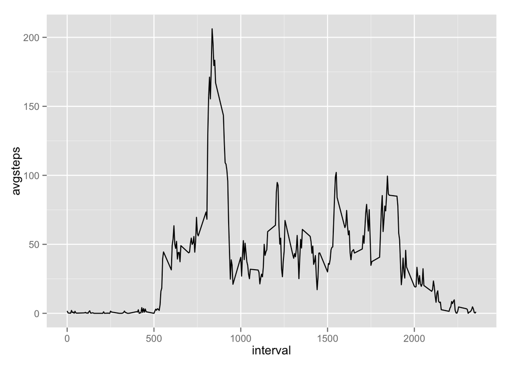

```r
avgdailysteps <- ddply(data,
                       .(interval),
                       function(df)
                           c(avgsteps = mean(df$steps, na.rm=TRUE)))
ggplot(avgdailysteps,
       aes(x=interval, y=avgsteps)) +
       geom_line()
```

```r
maxstepinterval <- avgdailysteps[which(avgdailysteps$avgsteps == max(avgdailysteps$avgsteps)), "interval"]
```

The average maximum number of steps occurs in the 835 interval of the day.

```r
missing <- sum(is.na(data$steps))
```

The number of missing values for step data is 2304.

In order to fill in all of the missing values in the dataset, the total median steps was imputed into all missing step values in the original data set.

```r
new_data <- data

new_data$steps[which(is.na(new_data$steps))] <- median_steps

new_totalsteps <- ddply(new_data,
                        .(date),
                        function(df)
                            c(totalsteps = sum(df$steps, na.rm=TRUE)))
```

Here’s a histogram of the new data:

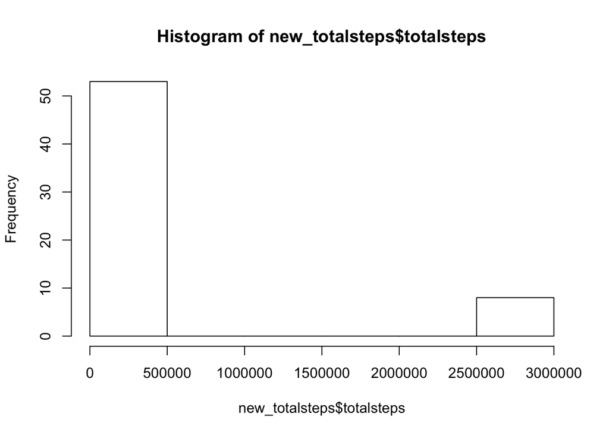

```r
hist(new_totalsteps$totalsteps)
```

I then calculated a new mean and median for total steps.

```r
new_mean <- mean(new_totalsteps$totalsteps, na.rm=TRUE)
new_median <- median(new_totalsteps$totalsteps, na.rm=TRUE)
```

The new mean total steps is 4.0198 × 10<sup>5</sup> and the new median total steps is 11458.

## Are there differences in activity patterns between weekdays and weekends?

I created a new factor variable in data for weekday or weekend.

```r
new_data$weekdays <- weekdays(new_data$date)
new_data$weekdays <- ifelse(new_data$weekdays == "Saturday" | new_data$weekdays == "Sunday",
                        "weekend",
                        "weekday")
new_data$weekdays <- factor(new_data$weekdays, levels=c("weekend", "weekday"))
```

Here’s a panel plot containing a time series of the intervals disaggregated by weekend or weekday. Instead of just showing weekend and weekday values as vertical facets, I decided to show them both horizontally and vertically to compare peaks better.

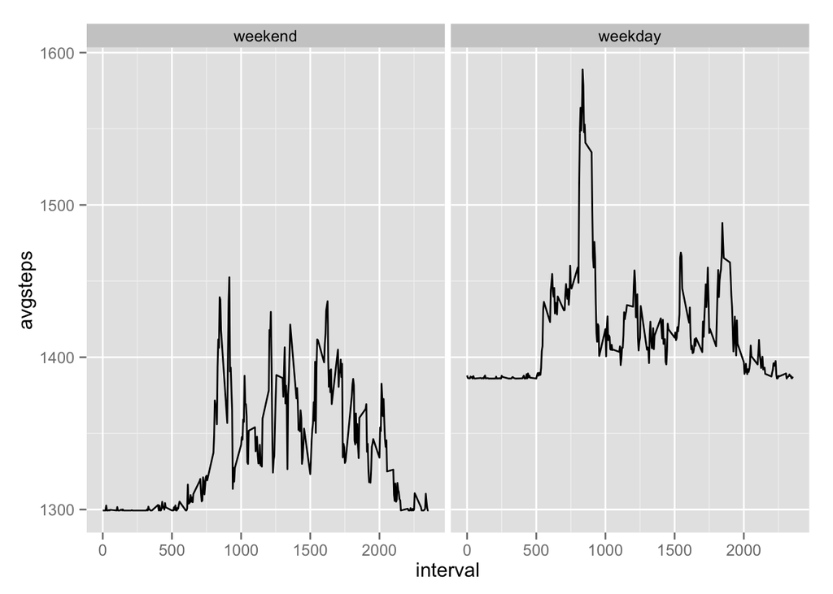

```r
avgdailysteps_wd <- ddply(new_data,
                          .(interval, weekdays),
                          function(df)
                              c(avgsteps = mean(df$steps, na.rm=TRUE)))

ggplot(avgdailysteps_wd, aes(x=interval, y=avgsteps)) +
       geom_line() +
       facet_grid(.~weekdays)
```

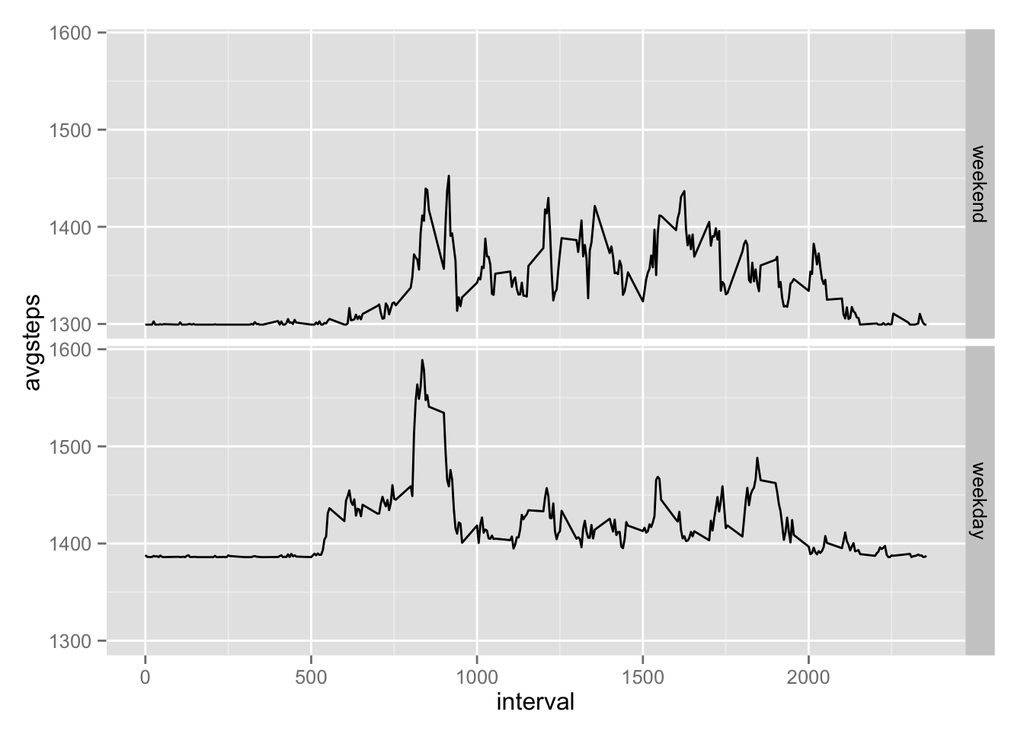

```r
ggplot(avgdailysteps_wd, aes(x=interval, y=avgsteps)) +
       geom_line() +
       facet_grid(weekdays~.)
```

From the panel plot, you can see that on average, weekday average step counts are higher than the weekend average step counts.